# DATS 6103 - Individual Project 3 - Kun Ei Kang

## Analysis of CFSAN Adverse Event Reporting System and Twitter

## Introduction

For the public health monitoring, FDA is releasing the public data for consumer complaint data. This CARES database contains information on product complaint reports submitted to FDA. It includes dietary supplements and food adversary incidents. Also, the FDA is trying to utilize SNS data like Twitter as real-time monitoring tools.

In this analysis, we will analyze the CARES database and twitter search API to analyze the adversary trends and products.

1. CARES Data Processing
2. Most Complained Products
3. Overall Outcomes from Incidents
4. Actual Injuries from incidents
5. Demographics of Patients
6. Product Analysis
7. Trend Adverse Incident Severity
8. Product distribution with Severity
9. Twitter Analysis on Top Severe Complaints Product
10. Prediction
11. Conclusion

### Data Sources

Data Sources are coming from Twitter and the CFSAN Adverse Event Reporting System (CAERS) database.

1. Twitter Search API - https://developer.twitter.com/en/docs/tweets/search/api-reference/get-search-tweets
2. CFSAN Adverse Event Reporting System (CAERS) database - https://www.fda.gov/media/128562/download

```python
from IPython.core.display import display, HTML
display(HTML("<style>.container { width:100% !important; }</style>"))
```

## 1. Data Processing

### CARES Processing

Clean up the CARES data using Pandas DataFrame

```python
# install all the dependencies
!pip install wget pandas openpyxl python-twitter flair TwitterSearch squarify
```

```python
import wget
import os.path
from os import path
# create data folder
!mkdir -p data
consumer_complaint_path = './data/CAERSASCII 2014-20190331.csv'

# prevent redownloading if it is there already
if(path.exists(consumer_complaint_path) == False):
    # download data from FDA
    consumer_complaint_path = wget.download("""https://www.fda.gov/media/128562/download""", "./data")
consumer_complaint_path
```

```
'./data/CAERSASCII 2014-20190331.csv'
```

```python
import pandas as pd
consumer_complaint = pd.read_csv(consumer_complaint_path, encoding = "ISO-8859-1")
consumer_complaint
```

|  | Report ID | CAERS Created Date | Date of Event | Product Type | Product | Product Code | Description | Patient Age | Age Units | Sex | MedDRA Preferred Terms | Outcomes |
| --- | --- | --- | --- | --- | --- | --- | --- | --- | --- | --- | --- | --- |
| 0 | 172940 | 1/1/2014 | NaN | SUSPECT | DANNON DANNON LITE & FIT GREEK YOGURT CHERRY | 09 | Milk/Butter/Dried Milk Prod | NaN | NaN | NaN | NAUSEA | Other Outcome |
| 1 | 172945 | 1/1/2014 | NaN | SUSPECT | SAVORITZ ORIGINAL BUTTERY ROUND CRACKERS | 03 | Bakery Prod/Dough/Mix/Icing | NaN | NaN | NaN | VOMITING | Other Outcome |
| 2 | 172944 | 1/1/2014 | NaN | SUSPECT | WELCH'S 100% GRAPE JUICE, FROM CONCENTRATE WIT... | 20 | Fruit/Fruit Prod | NaN | NaN | NaN | SLEEP DISORDER, SALIVARY GLAND DISORDER, ANXIETY | Other Outcome |
| 3 | 172937 | 1/1/2014 | NaN | SUSPECT | DAVID'S SUNFLOWER SEEDS, RANCH FLAVORED | 23 | Nuts/Edible Seed | NaN | NaN | NaN | TENDERNESS, PAIN, MUCOSAL ULCERATION, CAUSTIC ... | Hospitalization, Patient Visited Healthcare Pr... |
| 4 | 172934 | 1/1/2014 | 12/5/2013 | SUSPECT | VALUED NATIONAL PINE NUTS | 23 | Nuts/Edible Seed | NaN | NaN | NaN | HYPERSENSITIVITY, DYSGEUSIA | Other Outcome |
| ... | ... | ... | ... | ... | ... | ... | ... | ... | ... | ... | ... | ... |
| 80019 | 2019-CFS-003234 | 3/29/2019 | NaN | CONCOMITANT | VITAMIN B12 ( CYANOCOBALAMIN) | NaN | NaN | NaN | NaN | NaN | Rectal haemorrhage, Diarrhoea, Constipation | Medically Important |
| 80020 | 2019-CFS-003234 | 3/29/2019 | NaN | SUSPECT | PRESERVISION AREDS 2 MULTIVITAMIN SOFT GELS | 54 | Vit/Min/Prot/Unconv Diet(Human/Animal) | NaN | NaN | NaN | Rectal haemorrhage, Diarrhoea, Constipation | Medically Important |
| 80021 | 2019-CFS-003223 | 3/29/2019 | NaN | SUSPECT | CALTRATE 600 + VITAMIN D | 54 | Vit/Min/Prot/Unconv Diet(Human/Animal) | NaN | NaN | NaN | Foreign body, Choking | Medically Important |
| 80022 | 2019-CFS-003295 | 3/30/2019 | NaN | SUSPECT | 100% CREATINE MONOHYDRATE | 54 | Vit/Min/Prot/Unconv Diet(Human/Animal) | NaN | NaN | NaN | Vomiting projectile | Medically Important |
| 80023 | 2019-CFS-003289 | 3/30/2019 | NaN | SUSPECT | NeuroPro Gentlease Ready to Use Liqud Formula | 40 | Baby Food Products | NaN | NaN | NaN | NaN | Other Outcome |

80024 rows × 12 columns

## Crean up the data

```python
cc = consumer_complaint[['CAERS Created Date', 'Product', 'Outcomes']]
cc.loc[:,'year'] =  pd.to_datetime(cc['CAERS Created Date']).dt.year
cc.loc[:,'Product'] = cc['Product'].str.upper()
cc = cc.drop(['CAERS Created Date'], axis=1)

# filling missing data
cc.loc[:] = cc.fillna('')
# "EXEMPTION 4" is category which is redacted for the Trade Secrets. so filter out
cc1 = cc[cc['Product'] != 'EXEMPTION 4']

# Groups the Vitamins
vitamins_variations = ['FISH OIL', 'CALCIUM', 'MAGNESIUM', 'ZINC', 'OMEGA 3', 'VITAMIN']
def checkVitamin(x):
    if(x in vitamins_variations):
        return "VITAMIN"
    elif x.find("VITAMIN") != -1:
        return "VITAMIN"
    else:
        return x

# create new column product which is cleaned
cc1.loc[:,'product'] = cc1.Product.apply(checkVitamin)
# product count column
cc1.loc[:, 'product_count'] = cc1['Product']
```

```python
# Prepare the Top Most complained Products
cc2 = cc1[['product', 'product_count']]
cc2 = cc2.groupby(['product'])
cc2 = cc2.count().sort_values(['product_count'], ascending=False)
topN = 20
topProduct = cc2.head(topN)
```

```python
# map each outcome into number so we can sort it by outcome severity
outcomeDict = {
    'Death':11,
    'Life Threatening':10,
    'Disability':9,
    'Hospitalization':8,
    'Medically Important':7,
    'Patient Visited Healthcare Provider':6,
    'Other Seriousness':5,
    'Patient Visited ER':4,
    'Congenital Anomaly':3,
    'Required Intervention':2,
    'Other Outcome':1,
}

# this converts list of outcome to choose only one of the most severe symptom
def outcomeToSeverity(outcome):
    for o in outcome.split(","):
        o = o.strip()
        return  pd.to_numeric(outcomeDict[o])

# this converts list of outcome to choose only one of the most severe symptom and label
def outcomeToSeverityLabel(outcome):
    for o in outcome.split(","):
        o = o.strip()
        if(o != ''):
            return  o + " - " + str(outcomeDict[o])
    return ''

cc3 = cc1[['Outcomes', 'product_count']]
cc3 = cc3[cc3['product_count'] != 'VITAMIN']
# convert the Outcomes column to the most severity level and label
cc3.loc[:, 'outcomes'] = cc3['Outcomes'].apply(outcomeToSeverityLabel)
cc3 = cc3.groupby(['outcomes'])
cc3 = cc3.count().sort_values(['product_count'], ascending=False)
topOutcomes = cc3.head(topN)
# this is the most serious outcome list
topOutcomes
```

| outcomes | Outcomes | product_count |
| --- | --- | --- |
| Medically Important - 7 | 16956 | 16956 |
| Other Outcome - 1 | 10082 | 10082 |
| Hospitalization - 8 | 9385 | 9385 |
| Patient Visited Healthcare Provider - 6 | 8520 | 8520 |
| Life Threatening - 10 | 2923 | 2923 |
| Disability - 9 | 2294 | 2294 |
| Other Seriousness - 5 | 1599 | 1599 |
| Patient Visited ER - 4 | 741 | 741 |
| Death - 11 | 716 | 716 |
| Required Intervention - 2 | 82 | 82 |
| Congenital Anomaly - 3 | 39 | 39 |

## 2. Most Complainted Products

```python
import plotly.graph_objects as go
import plotly as plt

labels = topProduct.index.get_level_values('product')
# pie chart
fig = go.Figure(data=[go.Pie(labels=labels, values=topProduct.product_count, textinfo='label')])
fig.update_layout(title_text=f"Top {topN} Complained Products last 5 Years")
fig.show()
```

[interactive chart not shown]

The pie chart indicates that vitamin supplements are the most majority of the complaints. More than 90% are dietary supplements related (Vitamin, Super Beta Prostate, Biotin, Iron, etc).

Only 3 products are not vitamin supplements.

- Kratom - recreational drug
- Wen Cleaning Conditional - conditional product
- Monat Renew Shampoo - shampoo

## 3. Overall Outcomes from Incidents

```python
import plotly.graph_objects as go
import plotly as plt
plt.offline.init_notebook_mode()

labels = topOutcomes.index.get_level_values('outcomes')
fig = go.Figure(data=[go.Pie(labels=labels, values=topOutcomes['product_count'], textinfo='label')])
fig.update_layout(title_text=f"Top Outcome last 5 Years")
fig.show()
```

[interactive chart not shown]

## 4. Actual Injuries from incidents

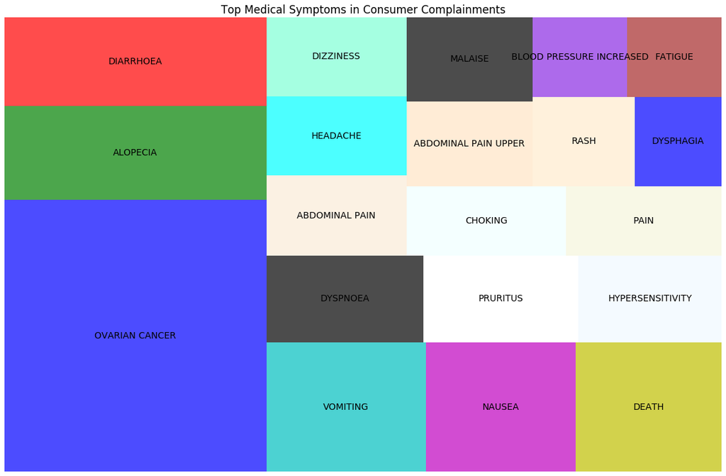

```python
import numpy as np
import matplotlib.pyplot as plt2
import squarify
from collections import Counter

# collect all medical terms
medical_terms = []
terms = consumer_complaint['MedDRA Preferred Terms']
# split comman separated terms
for term in terms:
    for o in str(term).split(","):
        o = o.strip().upper()
        medical_terms.append(o)

# calculate the each term occurrences into count
occurrences = Counter(medical_terms)

# collect them as list of dictionaries
term_occurrences = []
for key in occurrences:
    term_occurrences.append({'term': key, 'count': occurrences[key]})

#Convert it to dataframe
term_occurrencesDF = pd.DataFrame.from_dict(term_occurrences)
term_occurrencesDF = term_occurrencesDF.sort_values(['count'], ascending=False)
# display only top 10 values
top_term_occurrencesDF = term_occurrencesDF.head(topN)


# display the TreeMap
plt2.figure(figsize=(20, 13))
from matplotlib import colors as mcolors
colors = dict(mcolors.BASE_COLORS, **mcolors.CSS4_COLORS)
plt2.rc('font', size=14)
squarify.plot(sizes=top_term_occurrencesDF['count'], label=top_term_occurrencesDF['term'],
              color=colors, alpha=0.7)
plt2.axis('off')
plt2.title('Top Medical Symptoms in Consumer Complainments')
plt2.show()
```

Above TreeMap shows the distribution of the actual injuries. The most injury was ovarian cancer. These injuries include very serious like death and cancer.

## 5. Demograph of Patients

```python
import plotly.express as px

demograph = consumer_complaint[['Patient Age', 'Sex']]
demograph = demograph[demograph['Sex'] != 'NR']
demograph = demograph.dropna()
fig = px.histogram(demograph, x="Patient Age", color="Sex", histnorm='probability density', title="Patient Ages/Sex Distribution")
fig.show()
```

[interactive chart not shown]

- The histogram shows that the ages between 50 and 80 are the majority. This might be old ages are taking dietary supplements than younger ages more actively.

```python
# sub selects ages and product only
demographWithProduct = consumer_complaint[['Patient Age', 'Product']]
# remove "Exemption 4" since it is redacted by FDA
demographWithProduct = demographWithProduct[demographWithProduct['Product'] != 'EXEMPTION 4']
# clean up missing data
demographWithProduct = demographWithProduct.dropna()

# regroup the vitamin since it is too generic names
demographWithProduct.loc[:,'product'] = demographWithProduct.Product.apply(checkVitamin)
# grouping by age and product
demographWithProduct = demographWithProduct.groupby(['product', 'Patient Age']).count()
demographWithProduct = demographWithProduct.reset_index()
demographWithProduct = demographWithProduct.sort_values(['Product'], ascending=False)
# get top 100 products
topDemographWithProduct = demographWithProduct.head(100)
fig = px.histogram(topDemographWithProduct, x="Patient Age", color="product", histnorm='probability density', title="Patient Ages/Product Distribution")
fig.show()
```

[interactive chart not shown]

- The above histogram shows that age 40 - 50 is having most problems with "Wen Cleansing Conditioner".
- The age between 60 - 80, is having problems with "Super Beta Prostate" vitamin supplements.
- Between 80 - 90 ages is having problem with Presrvision Ared 2 formula soft gels.

## 6. Product Analysis

```python
# build top products that most complained for each years
cc2 = cc1[['product', 'product_count', 'year']]
cc2 = cc2.groupby(['product', 'year'])
cc2 = cc2.count().sort_values(['product_count'], ascending=False)
topProductYear = cc2
topProductYear.loc[:,'year'] = topProductYear.index.get_level_values('year')
topProductYear.loc[:,'product'] = topProductYear.index.get_level_values('product')
# remove Vitamin which was very generic terms and we would like to mointor specific brand, therefore it is removed.
topProductYear = topProductYear[topProductYear['product'] != 'VITAMIN']

# Plot the products over 5 years periods
traces = []
layout = go.Layout(
    title="Top Complained Product over 5 years",
    yaxis=dict(title='Complaintments'),
    xaxis=dict(title='Year'),
)
for year in range(2014, 2019+1):
    year_df = topProductYear[topProductYear['year'] == year]
    df = year_df.sort_values('product_count', ascending=False)
    df = df.head(10)
    for product in df['product']:
        df2 = df[df['product'] == product]
        traces.append(go.Bar(x=df2.year, y=df2.product_count, name=product))

fig = go.Figure(data=traces, layout=layout)
fig.show()
```

[interactive chart not shown]

This chart shows which products are spiking in the complaints database for each year. Based on this, we learn

- In years 2015, 2017, 2018, 2019, the supplement "Super Beta Prostate" is distant number one complained product
- However, in the year 2016, the "Wen Cleansing Conditioner" taking over the number one complained product.

```python
for year in range(2014, 2019+1):
    traces = []
    layout = go.Layout(
        title="Top Complaints over 5 years",
        yaxis=dict(title='Complaintments'),
        xaxis=dict(title='Year'),
    )
    year_df = topProductYear[topProductYear['year'] == year]
    df = year_df.sort_values('product_count', ascending=False)
    df = df.head(10)
    for product in df['product']:
        df2 = df[df['product'] == product]
        traces.append(go.Bar(x=df2.year, y=df2.product_count, name=product))

    fig = go.Figure(data=traces, layout=layout)
    fig.show()
```

[interactive chart not shown]

```python
import plotly.graph_objects as go
import plotly.express as px

Ranks = 5

df3 = topProductYear.drop(['year','product'], axis=1).reset_index()
dfs = []
for year in range(2014, 2018+1):
    year_df = df3[df3['year'] == year]
    df = year_df.sort_values('product_count', ascending=False)
    df = df.head(Ranks)
    dfs.append(df)

top = pd.concat(dfs)

fig = px.area(top, x="year", y="product_count",
                  color="product",
                  line_group="product", hover_name="product",
                  title=f'TOP {Ranks} Product Complaints over 5 years')
fig.show()
```

[interactive chart not shown]

For the year 2016, the incidents spike because of the "Wen cleansing" product.

## 7. Trend Adverse Incident Sevrity

```python
top5 = topProduct.reset_index()
top5 = top5[top5['product'] != 'VITAMIN']
top5 = top5.head(topN)
pd.set_option('mode.chained_assignment', None)
```

### Overall Complain Trends

```python
products = cc1
products = products[['year', 'Product']]
products_count = products.groupby(['year']).count()
products_count = products_count.reset_index()
products_count = products_count.sort_values(['year'], ascending=False)
products_count = products_count.head(50)
products_count = products_count[products_count['year'] != 2019]
products_count
# plot the line
import plotly.express as px
fig = px.line(products_count, x="year", y="Product", title="Overall Complaints Trends")
fig.show()
```

[interactive chart not shown]

Overall, the complaints are normalized after 2016.

```python
severe = cc
# remove non severe incidents
severe = severe[severe['Outcomes'] != 'Other Outcome']
# conver the outcomes to severity level with label
severe.loc[:, 'severity_label'] =  severe['Outcomes'].apply(outcomeToSeverityLabel)
# conver the outcomes to severity level number
severe.loc[:, 'severity'] =  severe['Outcomes'].apply(outcomeToSeverity)
# subselect high severity level : hospitalization or above
severe = severe[severe['severity'] > 5]
severeOutomes = severe[['year', 'Product']]

# group severe outcome by years
severeOutomes = severeOutomes.groupby(['year']).count()
severeOutomes = severeOutomes.reset_index()
# remove year 2019 since it doesn't have enough data
severeOutomes.loc[:] = severeOutomes[severeOutomes['year'] != 2019]
severeOutomes

# plot the line
import plotly.express as px
fig = px.line(severeOutomes, x="year", y="Product", title="Death, Life Threatening, hospitalization Trends")
fig.show()
```

[interactive chart not shown]

##### By looking at the above chart, the severe outcome is growing over the years. However, the increase has been slow down from 2016 to 2018.

### Individual Severity Trends Last 5 Years

```python
severe = cc1
severe = severe[severe['Outcomes'] != 'Other Outcome']
# conver the outcomes to severity level with label
severe.loc[:, 'severity_label'] =  severe['Outcomes'].apply(outcomeToSeverityLabel)
# conver the outcomes to severity level number
severe.loc[:, 'severity'] =  severe['Outcomes'].apply(outcomeToSeverity)
# subselect high severity level : Other Seriousness or above
severe = severe[severe['severity'] > 4]
severeOutomes = severe
severeOutomes = severeOutomes[['year', 'severity_label', 'Product']]
severeOutomes = severeOutomes.groupby(['year', 'severity_label']).count()
severeOutomes = severeOutomes.reset_index()
# remove year 2019 since it doesn't have enough data
severeOutomes = severeOutomes[severeOutomes['year'] != 2019]

# plot individual severity trends
import plotly.express as px
fig = px.line(severeOutomes, x="year", y="Product", color='severity_label')
fig.show()
```

[interactive chart not shown]

For each severity, the other seriousness is trending up over the years. However, death and hospitalization are reducing over the years.

## 8. Product distribution with Severity

```python
# get unique outcomes
outcomes1 = cc1.Outcomes.unique()
outcomes = set()

# split outcomes string to array outcome
for outcome in outcomes1:
    for o in outcome.split(","):
        # get unique outcome list
        outcomes.add(o.strip())

severe = cc1

# convert the outcome to serverity level
severe.loc[:, 'severity'] =  severe['Outcomes'].apply(outcomeToSeverity)
# remove all the vitamin since it is too generic name
severeProducts = severe[severe['product'] != 'VITAMIN']
severeProducts = severeProducts[['product', 'severity', 'product_count']]
severeProducts_severity = severeProducts[['product', 'severity']].groupby(['product']).mean()
severeProducts_count = severeProducts[['product', 'product_count']].groupby(['product']).count()

# combine calculated severity and product counts
severeProducts = pd.concat([severeProducts_severity, severeProducts_count], axis=1)
# get Top high severirty Products
severeProducts = severeProducts.sort_values(['severity', 'product_count'], ascending=False)
topSevereProducts = severeProducts.head(topN)
topSevereProducts

# get Top Products by Count
severeProductsCounts = severeProducts.sort_values(['product_count', 'severity'], ascending=False)
topSevereProductsCounts = severeProductsCounts.head(topN)
topSevereProductsCounts = topSevereProductsCounts.reset_index()
```

```python
import plotly.graph_objects as go

# Plot scatter charts
data=[go.Scatter(
    x=topSevereProductsCounts.severity,
    y=topSevereProductsCounts.product_count,
    mode='markers+text',
    text=topSevereProductsCounts['product'],
    textposition='bottom center',
    marker=dict(
        color=topSevereProductsCounts.severity,
        size= topSevereProductsCounts.product_count/10,
        showscale=True,
        colorbar=dict(
            title="Outcome Severity"
        )

    )
)]
layout = go.Layout(
    title="Severity by Incident Counts"
)
fig = go.Figure(data=data, layout=layout)
fig.show()
```

[interactive chart not shown]

To find the most adverse products in terms of size and severity, the chart shows that "Kratom" is the most adverse supplement.

- The product "Kratom" is a recreational drug and the report size is small. However, it is the most deadly product in the database.
- The product "Super Beta Prostate" is the most reported product and its severity is also high compared to other supplements.

```python
import plotly.graph_objects as go
# Display by counts and severity level
data=[go.Scatter(
    x=topSevereProductsCounts.product_count,
    y=topSevereProductsCounts.severity,
    mode='markers+text',
    text=topSevereProductsCounts['product'],
    textposition='bottom center',
    marker=dict(
        color=topSevereProductsCounts.severity,
        size= topSevereProductsCounts.product_count/10,
        showscale=True,
        colorbar=dict(
            title="Outcome Severity"
        )

    )
)]

layout = go.Layout(
    title="Severity by Incident Counts"
)

fig = go.Figure(data=data, layout=layout)
fig.show()
```

[interactive chart not shown]

The next highest deadly supplements are "All Day Energy Greens".

## 9. Twitter Analysis on Top Severe Complaints Product

### Search Twitter with top severe complained products

- Collect all twitter which is high-risk products and use it to monitor product usage and its problem.
- Filter out the twitter dataset with sentiment analysis and the Named Entity Recognition model. Using the NER Person tag to detect that twitter is company generated or personal tweets. then use sentiment analysis to figure out whether it is an adversary tweet or not.
- Plot out the Twitter dataset with CARE database data for 2019 years

```python
consumer_key='GKb7crsuMpoyhsjRH97mzFtUT'
consumer_secret='4syXklQTuGXLZJKyf5XR3E9vZV4OmImmP3x34EjzRrYYc6FcQd'
access_token_key='127221870-odn7W2Uv4NfbRuf69gzSoRdwy23hXxo0Cyjucs1Y'
access_token_secret='eFt2c0jtfLpkA5BRySJoKxzruMLObTRSJKmFWp2WRyLsY'
```

```python
from TwitterSearch import *
import time

# this personal Twitter API keys
ts = TwitterSearch(
            consumer_key = consumer_key,
            consumer_secret = consumer_secret,
            access_token = access_token_key,
            access_token_secret = access_token_secret
)

# Search Twitter API with product name
def searchTwitterDF(keyword):
    # This code is copied from https://pypi.org/project/TwitterSearch example code.
    results = []
    objs = []
    tso = TwitterSearchOrder()
    tso.set_keywords([keyword])
    tso.set_include_entities(True)

    # handle rate limit issue
    def my_callback_closure(current_ts_instance):
        queries, tweets_seen = current_ts_instance.get_statistics()
        print("queries ", queries)
        if queries > 0 and (queries % 5) == 0: # trigger delay every 5th query
            time.sleep(60) # sleep for 60 seconds

    for tweet in ts.search_tweets_iterable(tso, callback=my_callback_closure):
        tweet['product'] = keyword
        objs.append(tweet)
        # if there are too many tweets, then limit 300 tweets since the API has limit on personal API license.
        if(len(objs) > 300):
            return objs

    return objs

results = []
for index, product in enumerate(topSevereProductsCounts['product']):
    # encode special characters
    product = urllib.parse.quote(product)
    # search Twitter AP
    tweets = searchTwitterDF(product)
    print(index, " ", product, " found ", len(tweets))
    results.append(tweets);
```

```
queries  1
0   SUPER%20BETA%20PROSTATE  found  10
queries  2
1   WEN%20CLEANSING%20CONDITIONER  found  7
queries  3
queries  4
queries  5
2   BIOTIN  found  292
queries  6
3   PRESERVISION%20AREDS%202  found  8
queries  7
4   ALL%20DAY%20ENERGY%20GREENS  found  0
queries  8
queries  9
queries  10
queries  11
5   KRATOM  found  301
queries  12
6   SUPER%20BETA%20PROSTATE%20P3%20ADVANCED  found  3
queries  13
queries  14
queries  15
queries  16
7   WEN  found  301
queries  17
8   PRESERVISION%20AREDS%202%20FORMULA%20SOFT%20GELS%20%28CAPSULE%2C%20SOFT%29  found  0
queries  18
queries  19
queries  20
queries  21
9   IRON  found  301
queries  22
10   SUPER%20BETA%20VIRILITY%20BOOST  found  0
queries  23
11   CENTRUM%20SILVER  found  67
queries  24
queries  25
queries  26
queries  27
12   POTASSIUM  found  301
```

[output cut: 9 more lines]

```
queries  34
queries  35
16   COQ10  found  175
queries  36
queries  37
queries  38
queries  39
17   PROBIOTIC  found  301
queries  40
18   TRIPLE%20ACTION%20VIRILITY  found  0
queries  41
queries  42
queries  43
queries  44
19   MELATONIN  found  301
```

```python
import pickle

# save objects to pickle file helper function
def savePickle(objs, filename):
    outfile = open(filename,'wb')
    pickle.dump(objs,outfile)
    outfile.close()

# read pickle file to objects helper function
def readPickle(filename):
    infile = open(filename,'rb')
    new_obj = pickle.load(infile)
    infile.close()
    return new_obj

# since twitter search api is expensive and rate is limited, so save it to local first.
savePickle(results, "complained_products.pickle")
results2 = readPickle("complained_products.pickle")
```

### Classify the Tweeted Products using NLP

```python
import pickle
import urllib
import pandas as pd

# read saved twitter data sets
results2 = readPickle("complained_products.pickle")

# convert the twitter data object to dictionary object
rows = []
for tweet1 in results2:
    for tweet in tweet1:
        product = urllib.parse.unquote(tweet['product'])
        rows.append({'name': tweet['user']['name'], 'text': tweet['text'], 'product':product  })

# convert it to
df = pd.DataFrame.from_dict(rows)
```